# Homework 09

Author

Zhiyuan Ma (mazy2005)

## Question 1: Choosing an SVM kernel

I use all 462 rows (302 without CHD, 160 with CHD), predicting `chd` from `sbp`, `tobacco`, `ldl`, `adiposity`, `famhist`, `typea`, `obesity`, `alcohol`, and `age`. I code `famhist` as 1 for Absent and 2 for Present. There are no missing values or duplicate rows, and all predictors vary.

**Design fixed before fitting.** I compare 18 settings: three costs C = 0.1, 1, 10 for linear and each polynomial degree 2, 3, 4 (12 settings), plus the six RBF combinations of those costs and gamma = 0.01, 0.1. With standardized vectors z, the kernels are linear z’z*, polynomial (z’z*/9 + 1)^d, and RBF exp(-gamma ||z-z*||²). Polynomial gamma = 1/9 and coef0 = 1 are fixed. Fits use scikit-learn SVC, unweighted classes, tolerance 0.001, no iteration cap, and the default zero decision threshold. Polynomial settings have no effect on other kernels.

**Common manual folds.** Starting in CSV row order, NumPy `default_rng(43209)` shuffles indices separately for class 0 then class 1. I split each shuffled class with `array_split(..., 5)` and combine corresponding pieces. Fold sizes are 93, 93, 92, 92, 92. Every candidate uses these exact folds. Within each fitting fold, `StandardScaler` estimates the mean and population SD, then transforms fitting and validation data; no validation values enter that fit. For each candidate I average its five validation misclassification rates equally. Fold SD uses denominator 4.

| ID | Kernel | C | gamma | Mean CV error | Fold SD |
| --- | --- | --- | --- | --- | --- |
| 1 | Linear | 0.1 | – | 0.29215 | 0.05543 |
| 2 | Linear | 1 | – | 0.28777 | 0.05329 |
| 3 | Linear | 10 | – | 0.28777 | 0.05329 |
| 4 | Poly 2 | 0.1 | 1/9 | 0.27482 | 0.02622 |
| 5 | Poly 2 | 1 | 1/9 | 0.26835 | 0.04656 |
| 6 | Poly 2 | 10 | 1/9 | 0.29004 | 0.06015 |
| 7 | Poly 3 | 0.1 | 1/9 | 0.27705 | 0.03282 |
| 8 | Poly 3 | 1 | 1/9 | 0.30299 | 0.01946 |
| 9 | Poly 3 | 10 | 1/9 | 0.32471 | 0.03635 |
| 10 | Poly 4 | 0.1 | 1/9 | 0.28142 | 0.04087 |
| 11 | Poly 4 | 1 | 1/9 | 0.31166 | 0.03170 |
| 12 | Poly 4 | 10 | 1/9 | 0.35940 | 0.05189 |
| 13 | RBF | 0.1 | 0.01 | 0.34633 | 0.00205 |
| 14 | RBF | 0.1 | 0.1 | 0.34633 | 0.00205 |
| 15 | RBF | 1 | 0.01 | 0.27480 | 0.02814 |
| 16 | RBF | 1 | 0.1 | 0.28128 | 0.04176 |
| 17 | RBF | 10 | 0.01 | 0.28132 | 0.03928 |
| 18 | RBF | 10 | 0.1 | 0.31816 | 0.04157 |

**Preference.** I select the quadratic kernel with C = 1 and gamma = 1/9: mean CV error **0.26835** (124/462 pooled errors, which differs slightly from the unweighted fold mean). Its best RBF competitor (C = 1, gamma = 0.01) has mean error 0.27480, and the best linear model has 0.28777. The quadratic model permits interactions and curvature with lower observed error than the linear model. The small gap over RBF is not convincing evidence of a population advantage; selection among 18 settings also makes the minimum CV error optimistic. Larger C hurts the higher-degree polynomials here.

## Question 2: A short, explicitly invoked skill

**Using both sides of peer review.** [The review of my Homework 7 skill](https://github.com/mazy2005/stat432-fall2026/issues/3) recommends explicit study-design defaults, uncertainty bars, and dataset-specific limitations. I add a fixed seed, 30% holdout, five folds, an 18-setting default grid and tie rule; descriptive error bars; and a required limitations statement. From reviewing the other student’s skill in Homework 8, I retain the emphasis on concise wording, computational scope, and a mathematical explanation for choices. I do not promise that a skill will improve predictive accuracy.

**New skill.** The complete `svm-brief/SKILL.md` is appended after the one-page report. Its body has 25 lines, including blank lines, below the 50-line limit. It contains no dataset names, variable names, or observed results. Its description and body require explicit invocation; local `agents/openai.yaml` additionally sets `policy.allow_implicit_invocation: false`.

**Explicit invocation used:**

> Follow `homework/week-09/svm-brief/SKILL.md` to analyze `homework/week-09/data/saheart.csv`. The response is `chd`; use all nine remaining columns as predictors, coding `famhist` as 1 for Absent and 2 for Present.

The skill and grid were written before the model results were computed. For this application, the 70/30 stratified split uses `train_test_split(random_state=43209)` and manual five-fold assignment within its 323 development rows follows the Question 1 algorithm, also with seed 43209. Fold sizes are 66, 65, 64, 64, 64. The 139 test cases do not enter this tuning, scaling, or selection. Question 1 deliberately uses all observations, including these cases; its selected kernel does not alter this prespecified Question 2 protocol. Thus this is an internal holdout exercise, not new external validation.

The following is the full development grid; the one-page report on the next page summarizes the best setting per kernel. Exact ties favor linear, lower polynomial degree, then RBF, followed by smaller C and gamma.

| ID | Kernel | C | gamma | Mean CV error | Fold SD |
| --- | --- | --- | --- | --- | --- |
| 1 | Linear | 0.1 | – | 0.28782 | 0.07902 |
| 2 | Linear | 1 | – | 0.28475 | 0.06324 |
| 3 | Linear | 10 | – | 0.28475 | 0.06324 |
| 4 | Poly 2 | 0.1 | 1/9 | 0.27840 | 0.06108 |
| 5 | Poly 2 | 1 | 1/9 | 0.27546 | 0.04183 |
| 6 | Poly 2 | 10 | 1/9 | 0.31864 | 0.04164 |
| 7 | Poly 3 | 0.1 | 1/9 | 0.26921 | 0.05919 |
| 8 | Poly 3 | 1 | 1/9 | 0.31855 | 0.08195 |
| 9 | Poly 3 | 10 | 1/9 | 0.32186 | 0.09178 |
| 10 | Poly 4 | 0.1 | 1/9 | 0.28777 | 0.05816 |
| 11 | Poly 4 | 1 | 1/9 | 0.32499 | 0.08615 |
| 12 | Poly 4 | 10 | 1/9 | 0.39051 | 0.08853 |
| 13 | RBF | 0.1 | 0.01 | 0.34672 | 0.00448 |
| 14 | RBF | 0.1 | 0.1 | 0.34672 | 0.00448 |
| 15 | RBF | 1 | 0.01 | 0.27508 | 0.07073 |
| 16 | RBF | 1 | 0.1 | 0.26604 | 0.07210 |
| 17 | RBF | 10 | 0.01 | 0.25994 | 0.07341 |
| 18 | RBF | 10 | 0.1 | 0.32788 | 0.08510 |

## One-page SVM analysis report

**Data and method.** The 462 complete observations contain 160 CHD cases and 302 controls. All nine predictors vary; there are no duplicate rows. I use the supplied nine predictors and 1/2 family-history coding. SVMs accommodate this mix of numerical and binary predictors without a Gaussian predictor assumption. Scaling prevents numerical units from dominating distances. Linear boundaries provide a simple reference; polynomial degrees 2-4 allow interactions and curvature, while RBF permits local nonlinear structure.

With seed 43209, I reserve 139 stratified test cases and tune on 323 development cases using five shared, manually stratified folds. Scaling is fitted within each fitting fold. Eighteen settings compare C = 0.1, 1, 10 for every kernel, crossed with gamma = 0.01, 0.1 for RBF; polynomial gamma = 1/9 and coef0 = 1 are fixed. Classes are unweighted. Minimum mean CV error determines selection, with a prespecified simplicity tie rule. The table shows each kernel’s best candidate.

| Kernel | Best C | gamma | CV error | Descriptive SE |
| --- | --- | --- | --- | --- |
| Linear | 1 | – | 0.2847 | 0.0283 |
| Poly 2 | 1 | 1/9 | 0.2755 | 0.0187 |
| Poly 3 | 0.1 | 1/9 | 0.2692 | 0.0265 |
| Poly 4 | 0.1 | 1/9 | 0.2878 | 0.0260 |
| RBF | 10 | 0.01 | 0.2599 | 0.0328 |

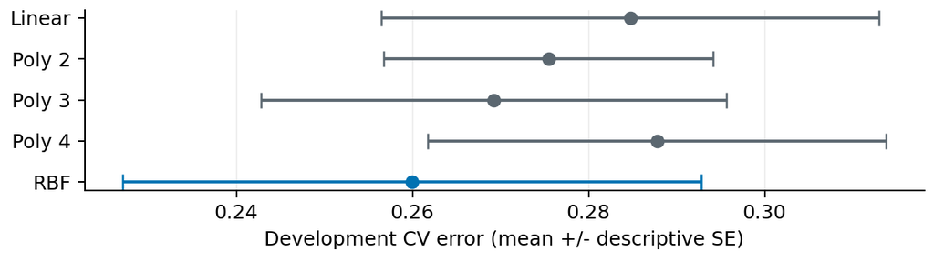

**Choice and evaluation.** The selected RBF SVM has **C = 10, gamma = 0.01**, mean development CV error **0.25994**. Its 0.00928 lead over the cubic model is smaller than the displayed fold variation; it is a numerical choice, not proof of superiority. Refit on all 323 development cases, it makes **39/139 test errors (0.28058)**, compared with **48/139 (0.34532)** for the training-majority rule. With true classes as rows and predicted classes as columns, its test confusion matrix is **[[79, 12], [27, 21]]** for class order [0, 1]. CHD sensitivity is **21/48 = 0.4375** and specificity **79/91 = 0.8681**. It misses more than half the CHD cases; overall accuracy conceals that weakness.

**Interpretation and limits.** RBF predicts via a nonlinear boundary in standardized predictor space; its scores are neither probabilities nor causal effects. Bars show fold SD/sqrt(5), descriptive only because training folds overlap. Selection and a single split are unstable in a small sample. Family-history coding imposes a numerical distance, skewed predictors can affect geometry, and performance may change with population or prevalence. No clinical decision rule is established. Question 1 reused all rows under a separate fixed protocol; this holdout is internal and does not provide external confirmation.

## Appendix: Complete `SKILL.md`

```markdown
---
name: svm-brief
description: "Fit and compare SVM classifiers and write a one-page analysis; use only when explicitly invoked."
---

Use only on explicit invocation; obtain data, response, predictors, and coding from that request.
Check sample size, class balance, missingness, types, duplicates, and predictor variation.
Explain suitability for SVM classification and any sampling or measurement limitations.
Unless overridden, use seed 43209, reserve a stratified 30% test set, and use five training folds.
Keep test observations out of tuning, preprocessing decisions, and report-driven model revisions.
Consider linear, polynomial degrees 2-4, and RBF kernels: simple boundary versus nonlinear alternatives.
Default to 18 settings: C in {0.1,1,10} for each linear/polynomial kernel;
for RBF cross C in {0.1,1,10} with gamma in {0.01,0.1}.
For polynomial kernels fix gamma=1/p and coef0=1, where p is the predictor count.
Use unweighted classes, tolerance 0.001, and the SVC decision threshold zero unless justified otherwise.
Assign reproducible stratified folds once and reuse them for every candidate.
Fit imputation if needed and standardization using fitting observations only, inside every fold.
Tune by mean fold misclassification rate; report all candidates outside the one-page report if needed.
Select minimum mean CV error; exact ties favor linear, lower polynomial degree, then RBF,
then smaller C and gamma. Do not treat tiny differences as convincing superiority.
Refit on all development observations and evaluate exactly once on the reserved test set.
Report test counts, error, confusion matrix, sensitivity, specificity, and majority-class baseline.
Interpret the decision boundary without causal claims or treating SVM scores as probabilities.
Produce a compact table of kernel-wise best settings and CV results plus a matching figure.
Show fold SD/sqrt(5) error bars for five folds; label them descriptive, not independent-sample CIs.
Keep the analysis report to one printed page at 11-point font, with methods, choice, numbers,
and dataset-specific limitations. Put code, full grids, and skill text outside that page.
Verify numerical calculations, leakage prevention, and the actual printed layout before delivery.
```

### Checks and reproducibility

The skill passed validation. All candidates converged. Checks confirmed disjoint folds, fitting-only scaler means, and CV statistics reconstructed from integer error counts. Test rates match the confusion matrix. Print inspection confirmed the analysis report fits one page at 11-point font; the appendix is outside that limit.